# Risk Factor Analysis

## Outcome Variable

**Outcome Variable:** whz

## Predictor Variables

**Intervention Variable:** vagbrth

**Adjustment Set:**

- arm
- sex
- W_mage
- meducyrs
- feducyrs
- hhwealth_quart
- W_mhtcm
- W_mwtkg
- W_mbmi
- single
- W_nrooms
- brthmon
- W_parity
- impfloor
- delta_W_mage
- delta_meducyrs
- delta_feducyrs
- delta_hhwealth_quart
- delta_W_mhtcm
- delta_W_mwtkg
- delta_W_mbmi
- delta_single
- delta_W_nrooms
- delta_brthmon
- delta_W_parity
- delta_impfloor

## Stratifying Variables

The analysis was stratified on these variable(s):

- agecat
- studyid
- country

## Data Summary

| agecat | studyid | country | vagbrth | n_cell | n |
| --- | --- | --- | --- | --- | --- |
| Birth | CMC-V-BCS-2002 | INDIA | 0 | 10 | 86 |
| Birth | CMC-V-BCS-2002 | INDIA | 1 | 76 | 86 |
| Birth | IRC | INDIA | 0 | 66 | 343 |
| Birth | IRC | INDIA | 1 | 277 | 343 |
| Birth | JiVitA-3 | BANGLADESH | 0 | 500 | 17985 |
| Birth | JiVitA-3 | BANGLADESH | 1 | 17485 | 17985 |
| Birth | JiVitA-4 | BANGLADESH | 0 | 71 | 2395 |
| Birth | JiVitA-4 | BANGLADESH | 1 | 2324 | 2395 |
| Birth | NIH-Crypto | BANGLADESH | 0 | 184 | 465 |
| Birth | NIH-Crypto | BANGLADESH | 1 | 281 | 465 |
| Birth | PROBIT | BELARUS | 0 | 1591 | 13817 |
| Birth | PROBIT | BELARUS | 1 | 12226 | 13817 |
| Birth | PROVIDE | BANGLADESH | 0 | 108 | 532 |
| Birth | PROVIDE | BANGLADESH | 1 | 424 | 532 |
| Birth | ZVITAMBO | ZIMBABWE | 0 | 1100 | 12814 |
| Birth | ZVITAMBO | ZIMBABWE | 1 | 11714 | 12814 |
| 6 months | CMC-V-BCS-2002 | INDIA | 0 | 25 | 368 |
| 6 months | CMC-V-BCS-2002 | INDIA | 1 | 343 | 368 |
| 6 months | IRC | INDIA | 0 | 68 | 408 |
| 6 months | IRC | INDIA | 1 | 340 | 408 |
| 6 months | JiVitA-3 | BANGLADESH | 0 | 1075 | 16705 |
| 6 months | JiVitA-3 | BANGLADESH | 1 | 15630 | 16705 |
| 6 months | JiVitA-4 | BANGLADESH | 0 | 337 | 4056 |
| 6 months | JiVitA-4 | BANGLADESH | 1 | 3719 | 4056 |
| 6 months | NIH-Crypto | BANGLADESH | 0 | 187 | 457 |
| 6 months | NIH-Crypto | BANGLADESH | 1 | 270 | 457 |
| 6 months | PROBIT | BELARUS | 0 | 1797 | 15757 |
| 6 months | PROBIT | BELARUS | 1 | 13960 | 15757 |
| 6 months | PROVIDE | BANGLADESH | 0 | 139 | 603 |
| 6 months | PROVIDE | BANGLADESH | 1 | 464 | 603 |
| 6 months | TanzaniaChild2 | TANZANIA, UNITED REPUBLIC OF | 0 | 189 | 2004 |
| 6 months | TanzaniaChild2 | TANZANIA, UNITED REPUBLIC OF | 1 | 1815 | 2004 |
| 6 months | ZVITAMBO | ZIMBABWE | 0 | 721 | 8437 |
| 6 months | ZVITAMBO | ZIMBABWE | 1 | 7716 | 8437 |
| 24 months | CMC-V-BCS-2002 | INDIA | 0 | 25 | 372 |
| 24 months | CMC-V-BCS-2002 | INDIA | 1 | 347 | 372 |
| 24 months | IRC | INDIA | 0 | 69 | 409 |
| 24 months | IRC | INDIA | 1 | 340 | 409 |
| 24 months | JiVitA-3 | BANGLADESH | 0 | 475 | 8555 |
| 24 months | JiVitA-3 | BANGLADESH | 1 | 8080 | 8555 |
| 24 months | JiVitA-4 | BANGLADESH | 0 | 323 | 4008 |
| 24 months | JiVitA-4 | BANGLADESH | 1 | 3685 | 4008 |
| 24 months | NIH-Crypto | BANGLADESH | 0 | 99 | 260 |
| 24 months | NIH-Crypto | BANGLADESH | 1 | 161 | 260 |
| 24 months | PROBIT | BELARUS | 0 | 463 | 3970 |
| 24 months | PROBIT | BELARUS | 1 | 3507 | 3970 |
| 24 months | PROVIDE | BANGLADESH | 0 | 137 | 579 |
| 24 months | PROVIDE | BANGLADESH | 1 | 442 | 579 |
| 24 months | TanzaniaChild2 | TANZANIA, UNITED REPUBLIC OF | 0 | 2 | 6 |
| 24 months | TanzaniaChild2 | TANZANIA, UNITED REPUBLIC OF | 1 | 4 | 6 |
| 24 months | ZVITAMBO | ZIMBABWE | 0 | 28 | 426 |
| 24 months | ZVITAMBO | ZIMBABWE | 1 | 398 | 426 |

The following strata were considered:

- agecat: 24 months, studyid: CMC-V-BCS-2002, country: INDIA
- agecat: 24 months, studyid: IRC, country: INDIA
- agecat: 24 months, studyid: JiVitA-3, country: BANGLADESH
- agecat: 24 months, studyid: JiVitA-4, country: BANGLADESH
- agecat: 24 months, studyid: NIH-Crypto, country: BANGLADESH
- agecat: 24 months, studyid: PROBIT, country: BELARUS
- agecat: 24 months, studyid: PROVIDE, country: BANGLADESH
- agecat: 24 months, studyid: TanzaniaChild2, country: TANZANIA, UNITED REPUBLIC OF
- agecat: 24 months, studyid: ZVITAMBO, country: ZIMBABWE
- agecat: 6 months, studyid: CMC-V-BCS-2002, country: INDIA
- agecat: 6 months, studyid: IRC, country: INDIA
- agecat: 6 months, studyid: JiVitA-3, country: BANGLADESH
- agecat: 6 months, studyid: JiVitA-4, country: BANGLADESH
- agecat: 6 months, studyid: NIH-Crypto, country: BANGLADESH
- agecat: 6 months, studyid: PROBIT, country: BELARUS
- agecat: 6 months, studyid: PROVIDE, country: BANGLADESH
- agecat: 6 months, studyid: TanzaniaChild2, country: TANZANIA, UNITED REPUBLIC OF
- agecat: 6 months, studyid: ZVITAMBO, country: ZIMBABWE
- agecat: Birth, studyid: CMC-V-BCS-2002, country: INDIA
- agecat: Birth, studyid: IRC, country: INDIA
- agecat: Birth, studyid: JiVitA-3, country: BANGLADESH
- agecat: Birth, studyid: JiVitA-4, country: BANGLADESH
- agecat: Birth, studyid: NIH-Crypto, country: BANGLADESH
- agecat: Birth, studyid: PROBIT, country: BELARUS
- agecat: Birth, studyid: PROVIDE, country: BANGLADESH
- agecat: Birth, studyid: ZVITAMBO, country: ZIMBABWE

### Dropped Strata

Some strata were dropped due to rare outcomes:

- agecat: 24 months, studyid: TanzaniaChild2, country: TANZANIA, UNITED REPUBLIC OF

## Methods Detail

We’re interested in the causal parameters $E[Y_a]$ for all values of $a \in \mathcal{A}$. These parameters represent the mean outcome if, possibly contrary to fact, we intervened to set all units to have $A=a$. Under the randomization and positivity assumptions, these are identified by the statistical parameters $\psi_a=E_W[E_{Y|A,W}(Y|A=a,W)]$. In addition, we’re interested in the mean of $Y$, $E[Y]$ under no intervention (the observed mean). We will estimate these parameters by using SuperLearner to fit the relevant likelihood factors – $E_{Y|A,W}(Y|A=a,W)$ and $p(A=a|W)$, and then updating our likelihood fit using a joint TMLE.

For unadjusted analyses ($W=\{\}$), initial likelihoods were estimated using Lrnr_glm to estimate the simple $E(Y|A)$ and Lrnr_mean to estimate $p(A)$. For adjusted analyses, a small library containing Lrnr_glmnet, Lrnr_xgboost, and Lrnr_mean was used.

Having estimated these parameters, we will then use the delta method to estimate relative risks and attributable risks relative to a prespecified baseline level of $A$.

# Results Detail

## Results Plots

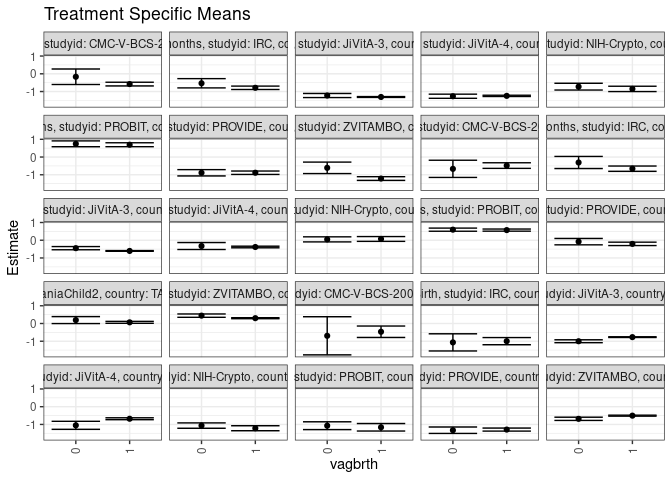

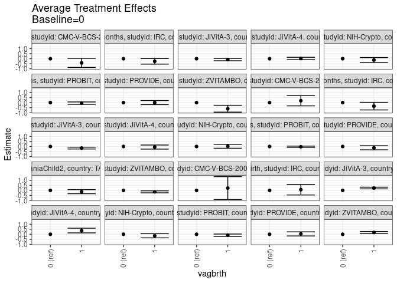

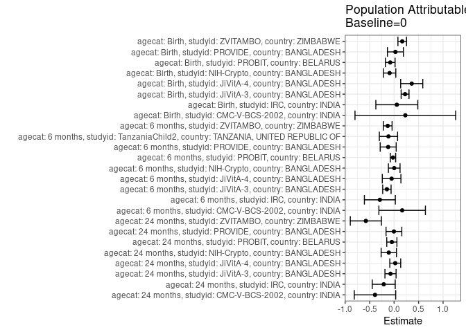

## Results Table

### Parameter: TSM

| agecat | studyid | country | intervention_level | baseline_level | estimate | ci_lower | ci_upper |
| --- | --- | --- | --- | --- | --- | --- | --- |
| Birth | CMC-V-BCS-2002 | INDIA | 0 | NA | -0.6938623 | -1.7690571 | 0.3813325 |
| Birth | CMC-V-BCS-2002 | INDIA | 1 | NA | -0.4658953 | -0.7880397 | -0.1437508 |
| Birth | IRC | INDIA | 0 | NA | -1.0662154 | -1.5504023 | -0.5820285 |
| Birth | IRC | INDIA | 1 | NA | -0.9967694 | -1.1985747 | -0.7949642 |
| Birth | JiVitA-3 | BANGLADESH | 0 | NA | -1.0014667 | -1.0828617 | -0.9200717 |
| Birth | JiVitA-3 | BANGLADESH | 1 | NA | -0.7695587 | -0.7889167 | -0.7502007 |
| Birth | JiVitA-4 | BANGLADESH | 0 | NA | -1.0487306 | -1.2749477 | -0.8225135 |
| Birth | JiVitA-4 | BANGLADESH | 1 | NA | -0.6787939 | -0.7324587 | -0.6251291 |
| Birth | NIH-Crypto | BANGLADESH | 0 | NA | -1.0633433 | -1.2145181 | -0.9121685 |
| Birth | NIH-Crypto | BANGLADESH | 1 | NA | -1.2134046 | -1.3546295 | -1.0721797 |
| Birth | PROBIT | BELARUS | 0 | NA | -1.0701587 | -1.2902697 | -0.8500478 |
| Birth | PROBIT | BELARUS | 1 | NA | -1.1598524 | -1.3719989 | -0.9477058 |
| Birth | PROVIDE | BANGLADESH | 0 | NA | -1.3253244 | -1.5073037 | -1.1433451 |
| Birth | PROVIDE | BANGLADESH | 1 | NA | -1.2890298 | -1.3746193 | -1.2034404 |
| Birth | ZVITAMBO | ZIMBABWE | 0 | NA | -0.6827415 | -0.7743811 | -0.5911019 |
| Birth | ZVITAMBO | ZIMBABWE | 1 | NA | -0.5037820 | -0.5309250 | -0.4766390 |
| 6 months | CMC-V-BCS-2002 | INDIA | 0 | NA | -0.6667690 | -1.1513439 | -0.1821942 |
| 6 months | CMC-V-BCS-2002 | INDIA | 1 | NA | -0.4812371 | -0.6388857 | -0.3235884 |
| 6 months | IRC | INDIA | 0 | NA | -0.3081637 | -0.6493279 | 0.0330005 |
| 6 months | IRC | INDIA | 1 | NA | -0.6566802 | -0.8065005 | -0.5068598 |
| 6 months | JiVitA-3 | BANGLADESH | 0 | NA | -0.4461895 | -0.5352549 | -0.3571242 |
| 6 months | JiVitA-3 | BANGLADESH | 1 | NA | -0.6025356 | -0.6223693 | -0.5827019 |
| 6 months | JiVitA-4 | BANGLADESH | 0 | NA | -0.3249400 | -0.5215926 | -0.1282875 |
| 6 months | JiVitA-4 | BANGLADESH | 1 | NA | -0.3806406 | -0.4258794 | -0.3354018 |
| 6 months | NIH-Crypto | BANGLADESH | 0 | NA | 0.0491383 | -0.0941366 | 0.1924132 |
| 6 months | NIH-Crypto | BANGLADESH | 1 | NA | 0.0729280 | -0.0626337 | 0.2084898 |
| 6 months | PROBIT | BELARUS | 0 | NA | 0.5968150 | 0.5088159 | 0.6848141 |
| 6 months | PROBIT | BELARUS | 1 | NA | 0.5726373 | 0.5128956 | 0.6323790 |
| 6 months | PROVIDE | BANGLADESH | 0 | NA | -0.0781842 | -0.2570215 | 0.1006530 |
| 6 months | PROVIDE | BANGLADESH | 1 | NA | -0.2043872 | -0.2997587 | -0.1090158 |
| 6 months | TanzaniaChild2 | TANZANIA, UNITED REPUBLIC OF | 0 | NA | 0.1921199 | -0.0035115 | 0.3877513 |
| 6 months | TanzaniaChild2 | TANZANIA, UNITED REPUBLIC OF | 1 | NA | 0.0649863 | 0.0098585 | 0.1201141 |
| 6 months | ZVITAMBO | ZIMBABWE | 0 | NA | 0.4423302 | 0.3492320 | 0.5354284 |
| 6 months | ZVITAMBO | ZIMBABWE | 1 | NA | 0.2992339 | 0.2723204 | 0.3261474 |
| 24 months | CMC-V-BCS-2002 | INDIA | 0 | NA | -0.1671407 | -0.6039267 | 0.2696452 |
| 24 months | CMC-V-BCS-2002 | INDIA | 1 | NA | -0.5803655 | -0.6849787 | -0.4757523 |
| 24 months | IRC | INDIA | 0 | NA | -0.5343819 | -0.7958023 | -0.2729616 |
| 24 months | IRC | INDIA | 1 | NA | -0.7897473 | -0.8866165 | -0.6928780 |
| 24 months | JiVitA-3 | BANGLADESH | 0 | NA | -1.2249669 | -1.3401165 | -1.1098173 |
| 24 months | JiVitA-3 | BANGLADESH | 1 | NA | -1.3074969 | -1.3316470 | -1.2833468 |
| 24 months | JiVitA-4 | BANGLADESH | 0 | NA | -1.2665845 | -1.3830314 | -1.1501376 |
| 24 months | JiVitA-4 | BANGLADESH | 1 | NA | -1.2446326 | -1.2802412 | -1.2090240 |
| 24 months | NIH-Crypto | BANGLADESH | 0 | NA | -0.7257246 | -0.9165047 | -0.5349445 |
| 24 months | NIH-Crypto | BANGLADESH | 1 | NA | -0.8529044 | -1.0034288 | -0.7023801 |
| 24 months | PROBIT | BELARUS | 0 | NA | 0.7444954 | 0.5803737 | 0.9086172 |
| 24 months | PROBIT | BELARUS | 1 | NA | 0.6935168 | 0.5820777 | 0.8049559 |
| 24 months | PROVIDE | BANGLADESH | 0 | NA | -0.8890767 | -1.0659739 | -0.7121796 |
| 24 months | PROVIDE | BANGLADESH | 1 | NA | -0.8862958 | -0.9824002 | -0.7901915 |
| 24 months | ZVITAMBO | ZIMBABWE | 0 | NA | -0.6095088 | -0.9323771 | -0.2866404 |
| 24 months | ZVITAMBO | ZIMBABWE | 1 | NA | -1.2138099 | -1.3177839 | -1.1098359 |

### Parameter: E(Y)

| agecat | studyid | country | intervention_level | baseline_level | estimate | ci_lower | ci_upper |
| --- | --- | --- | --- | --- | --- | --- | --- |
| Birth | CMC-V-BCS-2002 | INDIA | NA | NA | -0.4648256 | -0.7643210 | -0.1653302 |
| Birth | IRC | INDIA | NA | NA | -1.0105831 | -1.1973019 | -0.8238643 |
| Birth | JiVitA-3 | BANGLADESH | NA | NA | -0.7774729 | -0.7964631 | -0.7584827 |
| Birth | JiVitA-4 | BANGLADESH | NA | NA | -0.6890188 | -0.7414800 | -0.6365575 |
| Birth | NIH-Crypto | BANGLADESH | NA | NA | -1.1549785 | -1.2577390 | -1.0522180 |
| Birth | PROBIT | BELARUS | NA | NA | -1.1491782 | -1.3593933 | -0.9389630 |
| Birth | PROVIDE | BANGLADESH | NA | NA | -1.2984586 | -1.3752758 | -1.2216415 |
| Birth | ZVITAMBO | ZIMBABWE | NA | NA | -0.5168886 | -0.5428625 | -0.4909146 |
| 6 months | CMC-V-BCS-2002 | INDIA | NA | NA | -0.5026766 | -0.6536848 | -0.3516685 |
| 6 months | IRC | INDIA | NA | NA | -0.5989297 | -0.7344491 | -0.4634104 |
| 6 months | JiVitA-3 | BANGLADESH | NA | NA | -0.5935070 | -0.6130727 | -0.5739413 |
| 6 months | JiVitA-4 | BANGLADESH | NA | NA | -0.3758037 | -0.4184544 | -0.3331531 |
| 6 months | NIH-Crypto | BANGLADESH | NA | NA | 0.0515536 | -0.0469240 | 0.1500313 |
| 6 months | PROBIT | BELARUS | NA | NA | 0.5741099 | 0.5141290 | 0.6340908 |
| 6 months | PROVIDE | BANGLADESH | NA | NA | -0.1990907 | -0.2817968 | -0.1163845 |
| 6 months | TanzaniaChild2 | TANZANIA, UNITED REPUBLIC OF | NA | NA | 0.0769382 | 0.0241090 | 0.1297674 |
| 6 months | ZVITAMBO | ZIMBABWE | NA | NA | 0.3116179 | 0.2858347 | 0.3374010 |
| 24 months | CMC-V-BCS-2002 | INDIA | NA | NA | -0.5571505 | -0.6585247 | -0.4557763 |
| 24 months | IRC | INDIA | NA | NA | -0.7458150 | -0.8368180 | -0.6548120 |
| 24 months | JiVitA-3 | BANGLADESH | NA | NA | -1.2983928 | -1.3216893 | -1.2750962 |
| 24 months | JiVitA-4 | BANGLADESH | NA | NA | -1.2433658 | -1.2774681 | -1.2092634 |
| 24 months | NIH-Crypto | BANGLADESH | NA | NA | -0.8343077 | -0.9482310 | -0.7203844 |
| 24 months | PROBIT | BELARUS | NA | NA | 0.6981406 | 0.5843775 | 0.8119038 |
| 24 months | PROVIDE | BANGLADESH | NA | NA | -0.8928670 | -0.9755153 | -0.8102187 |
| 24 months | ZVITAMBO | ZIMBABWE | NA | NA | -1.1864319 | -1.2865891 | -1.0862748 |

### Parameter: ATE

| agecat | studyid | country | intervention_level | baseline_level | estimate | ci_lower | ci_upper |
| --- | --- | --- | --- | --- | --- | --- | --- |
| Birth | CMC-V-BCS-2002 | INDIA | 0 | 0 | 0.0000000 | 0.0000000 | 0.0000000 |
| Birth | CMC-V-BCS-2002 | INDIA | 1 | 0 | 0.2279670 | -0.9072765 | 1.3632106 |
| Birth | IRC | INDIA | 0 | 0 | 0.0000000 | 0.0000000 | 0.0000000 |
| Birth | IRC | INDIA | 1 | 0 | 0.0694460 | -0.4562554 | 0.5951473 |
| Birth | JiVitA-3 | BANGLADESH | 0 | 0 | 0.0000000 | 0.0000000 | 0.0000000 |
| Birth | JiVitA-3 | BANGLADESH | 1 | 0 | 0.2319080 | 0.1490206 | 0.3147954 |
| Birth | JiVitA-4 | BANGLADESH | 0 | 0 | 0.0000000 | 0.0000000 | 0.0000000 |
| Birth | JiVitA-4 | BANGLADESH | 1 | 0 | 0.3699367 | 0.1371148 | 0.6027586 |
| Birth | NIH-Crypto | BANGLADESH | 0 | 0 | 0.0000000 | 0.0000000 | 0.0000000 |
| Birth | NIH-Crypto | BANGLADESH | 1 | 0 | -0.1500613 | -0.3571075 | 0.0569849 |
| Birth | PROBIT | BELARUS | 0 | 0 | 0.0000000 | 0.0000000 | 0.0000000 |
| Birth | PROBIT | BELARUS | 1 | 0 | -0.0896936 | -0.2018889 | 0.0225016 |
| Birth | PROVIDE | BANGLADESH | 0 | 0 | 0.0000000 | 0.0000000 | 0.0000000 |
| Birth | PROVIDE | BANGLADESH | 1 | 0 | 0.0362946 | -0.1646412 | 0.2372303 |
| Birth | ZVITAMBO | ZIMBABWE | 0 | 0 | 0.0000000 | 0.0000000 | 0.0000000 |
| Birth | ZVITAMBO | ZIMBABWE | 1 | 0 | 0.1789595 | 0.0835137 | 0.2744052 |
| 6 months | CMC-V-BCS-2002 | INDIA | 0 | 0 | 0.0000000 | 0.0000000 | 0.0000000 |
| 6 months | CMC-V-BCS-2002 | INDIA | 1 | 0 | 0.1855320 | -0.3229930 | 0.6940569 |
| 6 months | IRC | INDIA | 0 | 0 | 0.0000000 | 0.0000000 | 0.0000000 |
| 6 months | IRC | INDIA | 1 | 0 | -0.3485164 | -0.7257090 | 0.0286761 |
| 6 months | JiVitA-3 | BANGLADESH | 0 | 0 | 0.0000000 | 0.0000000 | 0.0000000 |
| 6 months | JiVitA-3 | BANGLADESH | 1 | 0 | -0.1563460 | -0.2455825 | -0.0671095 |
| 6 months | JiVitA-4 | BANGLADESH | 0 | 0 | 0.0000000 | 0.0000000 | 0.0000000 |
| 6 months | JiVitA-4 | BANGLADESH | 1 | 0 | -0.0557006 | -0.2573005 | 0.1458993 |
| 6 months | NIH-Crypto | BANGLADESH | 0 | 0 | 0.0000000 | 0.0000000 | 0.0000000 |
| 6 months | NIH-Crypto | BANGLADESH | 1 | 0 | 0.0237897 | -0.1738685 | 0.2214480 |
| 6 months | PROBIT | BELARUS | 0 | 0 | 0.0000000 | 0.0000000 | 0.0000000 |
| 6 months | PROBIT | BELARUS | 1 | 0 | -0.0241777 | -0.0861447 | 0.0377894 |
| 6 months | PROVIDE | BANGLADESH | 0 | 0 | 0.0000000 | 0.0000000 | 0.0000000 |
| 6 months | PROVIDE | BANGLADESH | 1 | 0 | -0.1262030 | -0.3298280 | 0.0774220 |
| 6 months | TanzaniaChild2 | TANZANIA, UNITED REPUBLIC OF | 0 | 0 | 0.0000000 | 0.0000000 | 0.0000000 |
| 6 months | TanzaniaChild2 | TANZANIA, UNITED REPUBLIC OF | 1 | 0 | -0.1271336 | -0.3307389 | 0.0764717 |
| 6 months | ZVITAMBO | ZIMBABWE | 0 | 0 | 0.0000000 | 0.0000000 | 0.0000000 |
| 6 months | ZVITAMBO | ZIMBABWE | 1 | 0 | -0.1430963 | -0.2398917 | -0.0463009 |
| 24 months | CMC-V-BCS-2002 | INDIA | 0 | 0 | 0.0000000 | 0.0000000 | 0.0000000 |
| 24 months | CMC-V-BCS-2002 | INDIA | 1 | 0 | -0.4132248 | -0.8638841 | 0.0374345 |
| 24 months | IRC | INDIA | 0 | 0 | 0.0000000 | 0.0000000 | 0.0000000 |
| 24 months | IRC | INDIA | 1 | 0 | -0.2553653 | -0.5356822 | 0.0249516 |
| 24 months | JiVitA-3 | BANGLADESH | 0 | 0 | 0.0000000 | 0.0000000 | 0.0000000 |
| 24 months | JiVitA-3 | BANGLADESH | 1 | 0 | -0.0825300 | -0.2004039 | 0.0353440 |
| 24 months | JiVitA-4 | BANGLADESH | 0 | 0 | 0.0000000 | 0.0000000 | 0.0000000 |
| 24 months | JiVitA-4 | BANGLADESH | 1 | 0 | 0.0219519 | -0.0982875 | 0.1421913 |
| 24 months | NIH-Crypto | BANGLADESH | 0 | 0 | 0.0000000 | 0.0000000 | 0.0000000 |
| 24 months | NIH-Crypto | BANGLADESH | 1 | 0 | -0.1271798 | -0.3722122 | 0.1178525 |
| 24 months | PROBIT | BELARUS | 0 | 0 | 0.0000000 | 0.0000000 | 0.0000000 |
| 24 months | PROBIT | BELARUS | 1 | 0 | -0.0509786 | -0.1679221 | 0.0659648 |
| 24 months | PROVIDE | BANGLADESH | 0 | 0 | 0.0000000 | 0.0000000 | 0.0000000 |
| 24 months | PROVIDE | BANGLADESH | 1 | 0 | 0.0027809 | -0.1984612 | 0.2040230 |
| 24 months | ZVITAMBO | ZIMBABWE | 0 | 0 | 0.0000000 | 0.0000000 | 0.0000000 |
| 24 months | ZVITAMBO | ZIMBABWE | 1 | 0 | -0.6043011 | -0.9437371 | -0.2648651 |

### Parameter: PAR

| agecat | studyid | country | intervention_level | baseline_level | estimate | ci_lower | ci_upper |
| --- | --- | --- | --- | --- | --- | --- | --- |
| Birth | CMC-V-BCS-2002 | INDIA | 0 | NA | 0.2290367 | -0.7986843 | 1.2567577 |
| Birth | IRC | INDIA | 0 | NA | 0.0556323 | -0.3726094 | 0.4838740 |
| Birth | JiVitA-3 | BANGLADESH | 0 | NA | 0.2239938 | 0.1437440 | 0.3042436 |
| Birth | JiVitA-4 | BANGLADESH | 0 | NA | 0.3597118 | 0.1340336 | 0.5853900 |
| Birth | NIH-Crypto | BANGLADESH | 0 | NA | -0.0916352 | -0.2177529 | 0.0344825 |
| Birth | PROBIT | BELARUS | 0 | NA | -0.0790195 | -0.1780841 | 0.0200452 |
| Birth | PROVIDE | BANGLADESH | 0 | NA | 0.0268658 | -0.1361357 | 0.1898672 |
| Birth | ZVITAMBO | ZIMBABWE | 0 | NA | 0.1658529 | 0.0780888 | 0.2536170 |
| 6 months | CMC-V-BCS-2002 | INDIA | 0 | NA | 0.1640924 | -0.3107310 | 0.6389159 |
| 6 months | IRC | INDIA | 0 | NA | -0.2907660 | -0.6066560 | 0.0251240 |
| 6 months | JiVitA-3 | BANGLADESH | 0 | NA | -0.1473175 | -0.2328904 | -0.0617446 |
| 6 months | JiVitA-4 | BANGLADESH | 0 | NA | -0.0508637 | -0.2406653 | 0.1389378 |
| 6 months | NIH-Crypto | BANGLADESH | 0 | NA | 0.0024153 | -0.1164705 | 0.1213012 |
| 6 months | PROBIT | BELARUS | 0 | NA | -0.0227050 | -0.0775797 | 0.0321696 |
| 6 months | PROVIDE | BANGLADESH | 0 | NA | -0.1209064 | -0.2840496 | 0.0422368 |
| 6 months | TanzaniaChild2 | TANZANIA, UNITED REPUBLIC OF | 0 | NA | -0.1151817 | -0.3014338 | 0.0710704 |
| 6 months | ZVITAMBO | ZIMBABWE | 0 | NA | -0.1307123 | -0.2199459 | -0.0414787 |
| 24 months | CMC-V-BCS-2002 | INDIA | 0 | NA | -0.3900098 | -0.8128707 | 0.0328511 |
| 24 months | IRC | INDIA | 0 | NA | -0.2114331 | -0.4463604 | 0.0234943 |
| 24 months | JiVitA-3 | BANGLADESH | 0 | NA | -0.0734258 | -0.1870402 | 0.0401886 |
| 24 months | JiVitA-4 | BANGLADESH | 0 | NA | 0.0232187 | -0.0883193 | 0.1347567 |
| 24 months | NIH-Crypto | BANGLADESH | 0 | NA | -0.1085831 | -0.2648015 | 0.0476354 |
| 24 months | PROBIT | BELARUS | 0 | NA | -0.0463548 | -0.1501652 | 0.0574557 |
| 24 months | PROVIDE | BANGLADESH | 0 | NA | -0.0037903 | -0.1647693 | 0.1571888 |
| 24 months | ZVITAMBO | ZIMBABWE | 0 | NA | -0.5769231 | -0.8946149 | -0.2592314 |